# Thesis Progress Report

Erin Johnston

```r
library(tidyverse)
library(here)
library(knitr)
```

# Questions

1. How well does a regional-scale oceanographi index, like MOCI, correlate with Blue rockfish CPUE in the nearshore environment off the central coast of California?
1. Are these correlations different for different life stages (i.e., juvenile vs adult Blue rockfish)?
2. Do marine heatwave(MHW) years have a disproportionate impact on the relationship between oceanographic parameters and Blue rockfish CPUE?
3. What is the importance of the component parts of MOCI in determining the relationship between oceanographic parameters and Blue rockfish CPUE? (work in progress)
4. What are the impacts of MHWs on Blue rockfish growth? (work in progress)

# Field Methods

Fishing trips happened at one of four [sampling areas](https://erinmarjo.github.io/CCFRP/20_VIS_interactive-widget-maps.html). Each area spans two site types, an unfished MPA and an adjacent, fished reference site (REF). Within each site, sampling was performed in accordance with standard CCFRP procedures (Star *et al.*, 2015).

# Data Cleaning

Details for cleaning the dataset, including the 2020 data, can be found on [this page](https://erinmarjo.github.io/CCFRP/30_full_master_df_creation.html), which outlines how the master dataset was created.

# Part I: Juvenile Blue Rockfish and MHWs

The Multivariate Ocean Climate Indicator includes several local parameters, including upwelling index, sea level, alongshore wind, sea surface temperature, air temperature, sea level pressure, and regional climate indices, including the Multivariate ENSO index (MEI), the Pacific Decadal Oscillation (PDO), and Northern Oscillation Index (NOI). MOCI is split into three regions in California: Southern, Central, and Northern. For the purposes of this study, spatial indicator values for Central California were used, which include the area between Point conception ($34.5^oN$) to Point Reyes ($38^oN$). Similar to ENSO and PDO, high MOCI values represent warm water temperature and decreased upwelling, while low MOCI values represent cool water temperatures and increased upwelling (García-Reyes and Sydeman, 2017). MOCI captures El Nino events as well as Marine Heatwave events like the 2014-2015 North Pacific marine heat wave (‘The Blob’).

For building cross correlation figures, see [this page](https://erinmarjo.github.io/CCFRP/31_blue_cross_corr_2020.html)

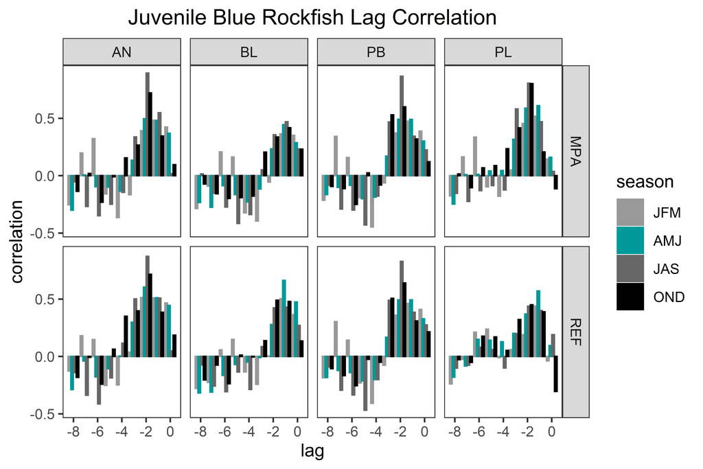

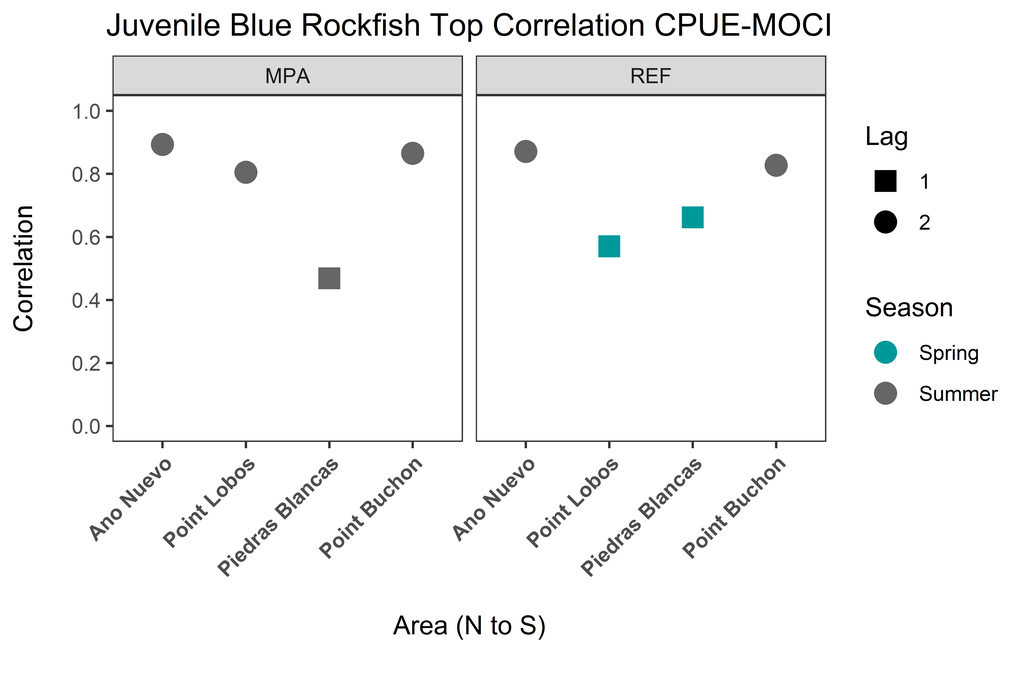

Top Correlations: Juvenile Blue Rockfish

| area | site | season | lag | correlation |
| --- | --- | --- | --- | --- |
| AN | MPA | JAS | -2 | 0.8934731 |
| AN | REF | JAS | -2 | 0.8713385 |
| BL | MPA | JAS | -1 | 0.4686977 |
| BL | REF | AMJ | -1 | 0.6621939 |
| PB | MPA | JAS | -2 | 0.8653707 |
| PB | REF | JAS | -2 | 0.8275121 |
| PL | MPA | JAS | -2 | 0.8050404 |
| PL | REF | AMJ | -1 | 0.5701478 |

# Part II: Adult Blue Rockfish and MHWs

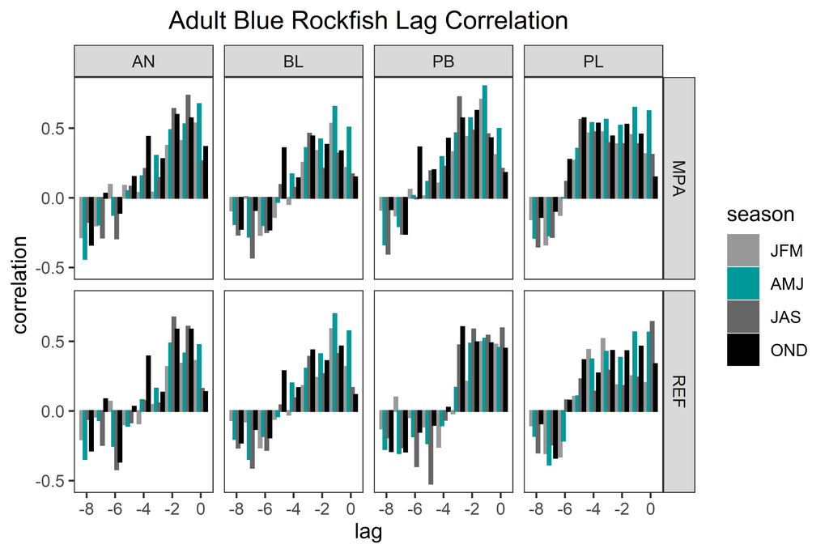

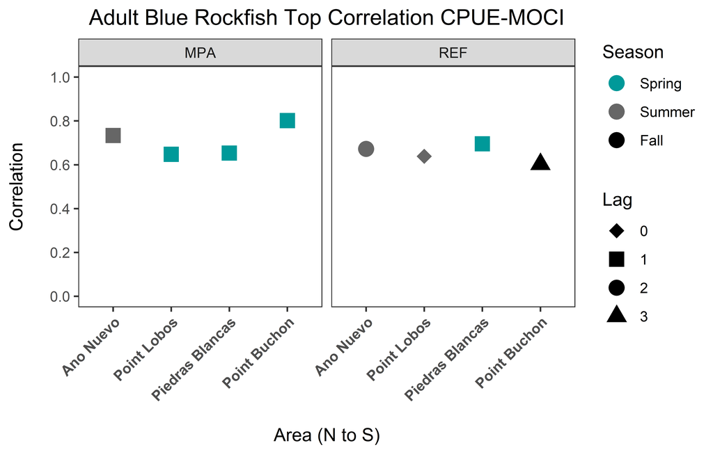

Top Correlations: Adult Blue Rockfish

| area | site | season | lag | correlation |
| --- | --- | --- | --- | --- |
| AN | MPA | JAS | -1 | 0.7335439 |
| AN | REF | JAS | -2 | 0.6721202 |
| BL | MPA | AMJ | -1 | 0.6534168 |
| BL | REF | AMJ | -1 | 0.6957565 |
| PB | MPA | AMJ | -1 | 0.8016120 |
| PB | REF | OND | -3 | 0.6027510 |
| PL | MPA | AMJ | -1 | 0.6477663 |
| PL | REF | JAS | 0 | 0.6388903 |

# Part III: Importance of MHW Years

If marine heatwave years have a disproportionately important impact on the correlation between CPUE and MOCI for juvenile blue rockfish, excluding those year will lower the correlation.

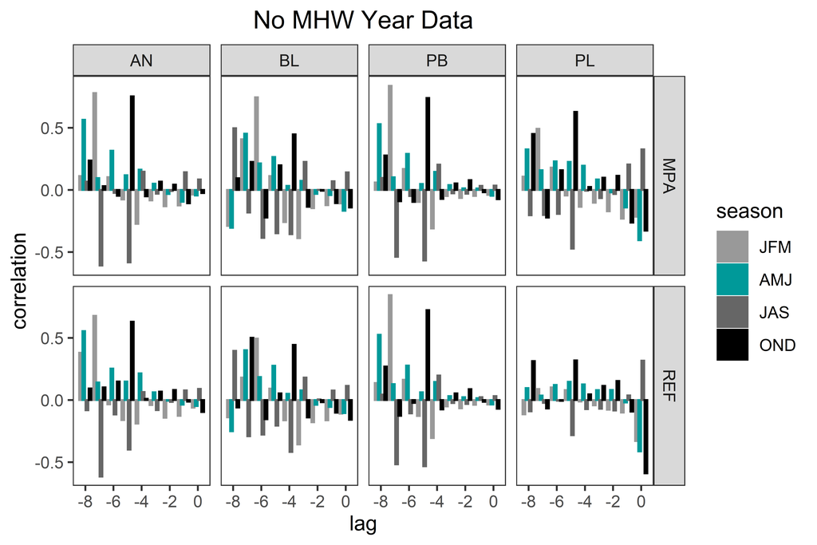

To ensure that these correlations were not lower simply because data were missing, three other years were excluded from cross correlation.

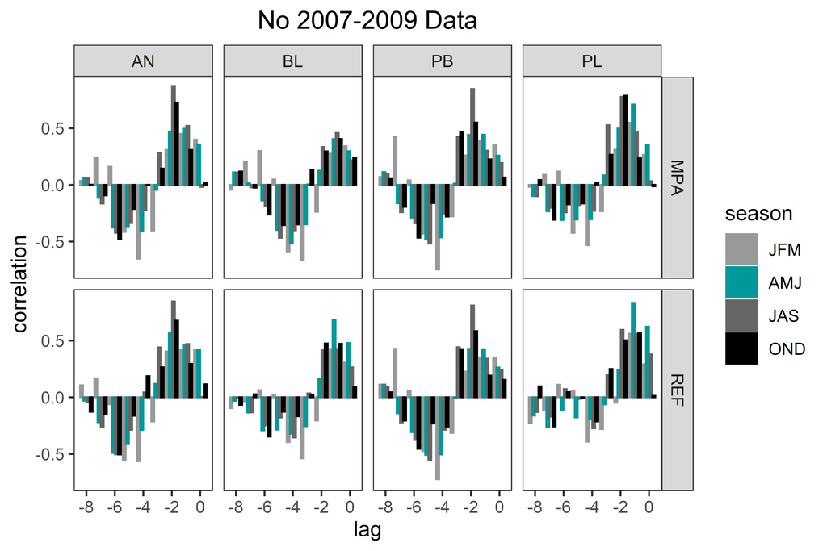

Multiple sets of years were excluded. For full representation, click [here](https://erinmarjo.github.io/CCFRP/28_DATA_year_exclusion.html)

# Part IV: Importance of Component Parts of MOCI

Two potential hypotheses about the driver of the correlation between MOCI and Blue rockfish CPUE (juveniles and adults) have emerged. We can use data from MPAs to remove the potential confounding factors of direct fishing pressure on *S. mystinus* populations. Ocean conditions two years before spikes in *S. mystinus* CPUE included warm water, positive PDO phase, and the El Nino phase of ENSO. Upwelling was supressed during these events and phytoplankton blooms were subsequently smaller. Despite smaller bloom magnitude, there was still a Spring time peak and this peak had shifted earlier in the year. We are currently experiencing cooler ocean conditions (2021), but there has been a shift to earlier peaks of phytoplankton again. Therefore, if we see a spike in *S. mystinus* CPUE in two years, the correlations between oceanography and CPUE may be driven by the timing of phytoplankton blooms (food availability driver hypothesis?). If we do not see a spike in S mystinus CPUE in two year, the correlations between oceanography and CPUE may be driven by ocean temperature regimes (MHW driver hypothesis?)

More coming soon…

## PDO

The monthly PDO index used for this correlation is the NOAA NCEI reconstruction of anomalous sea surface temperatures from [ERSST Version 5](https://www.ncdc.noaa.gov/data-access/marineocean-data/extended-reconstructed-sea-surface-temperature-ersst-v5) and can be found at https://www.ncdc.noaa.gov/teleconnections/pdo/. Full code for correlations between CPUE and PDO can be found [here](https://erinmarjo.github.io/CCFRP/32_pdo_blue_cross_corr.html)

### Juvenile Blue Rockfish and PDO

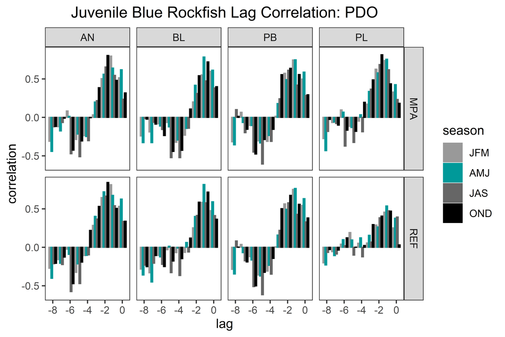

Top Correlations: Juvenile Blue Rockfish - PDO

| area | site | season | lag | correlation |
| --- | --- | --- | --- | --- |
| AN | MPA | OND | -2 | 0.8046696 |
| AN | REF | OND | -2 | 0.8433354 |
| BL | MPA | AMJ | -1 | 0.7847764 |
| BL | REF | AMJ | -1 | 0.8163620 |
| PB | MPA | AMJ | -1 | 0.7491590 |
| PB | REF | AMJ | -1 | 0.7653192 |
| PL | MPA | OND | -2 | 0.8142187 |
| PL | REF | AMJ | -1 | 0.5375076 |

### Adult Blue Rockfish and PDO

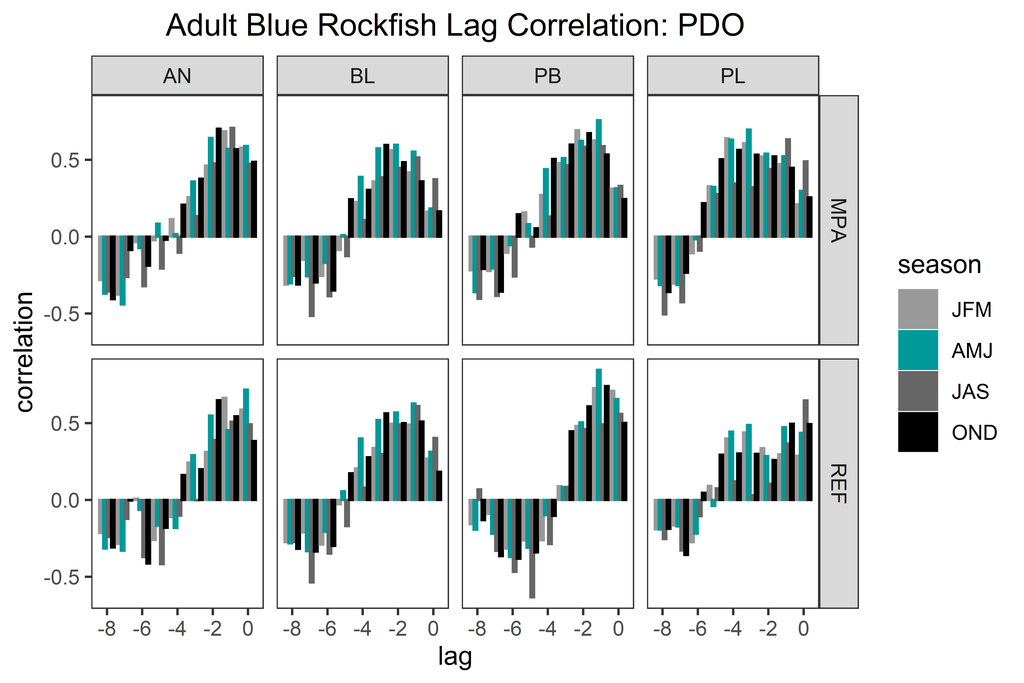

Top Correlations: Adult Blue Rockfish - PDO

| area | site | season | lag | correlation |
| --- | --- | --- | --- | --- |
| AN | MPA | JAS | -1 | 0.7068726 |
| AN | REF | AMJ | 0 | 0.7168876 |
| BL | MPA | AMJ | -2 | 0.5976857 |
| BL | REF | AMJ | -1 | 0.6267084 |
| PB | MPA | AMJ | -1 | 0.7571459 |
| PB | REF | AMJ | -1 | 0.8465636 |
| PL | MPA | AMJ | -3 | 0.6959978 |
| PL | REF | JAS | 0 | 0.6472783 |

## Local Oceanographic Parameters

Information regarding the relationship between wind stress, wind stress curl, coastal upwelling, and the timing of Spring phytoplankton blooms coming soon. Reference: meeting with A. Pasulka and J. Gilbert on 2021-08-18

# Part V: Impacts of MHW on Blue Rockfish Growth

Cohort analysis and information from CCFRP tag returns coming soon.

# References

García-Reyes, M., & Sydeman, W. J. (2017). California Multivariate Ocean Climate Indicator (MOCI) and marine ecosystem dynamics. *Ecological Indicators*, 9.

Mantua, N. J., & Hare, S. R. (2002). The Pacific Decadal Oscillation. *Journal of Oceanography*, 58, 35–44.

Starr, R. M., Wendt, D. E., Barnes, C. L., Marks, C. I., Malone, D., Waltz, G., … Yochum, N. (2015). Variation in Responses of Fishes across Multiple Reserves within a Network of Marine Protected Areas in Temperate Waters. *PLoS ONE*, 10.